# Protestantische Arbeitsethik

Simon Büttner

2019-09-01

# Protestantische Arbeitsethik

Mein erster Post soll Einblick darin geben, wie ein Psychologe grundsätzlich versucht, bestimmte psychologische Konstrukte/Eigenschaften, die er sich ausgedacht hat, empirisch zu untersuchen. Den eigentlich sehr spannenden Prozess der Itemgenerierung lassen wir hier außen vor und steigen bei der empirischen Überprüfung der Items ein. Items sind die einzelnen Aufgaben, die man in einem Test bearbeitet. Bei Persönlichkeitstests sind es Aussagen wie “Ich lese gerne Blogs”, die man z.B. von 1-5 danach bewerten soll, inwiefern man diesen zustimmt. Bei solchen Einschätzungen von 1-5 spricht man dann von Likert-Skalen bzw. einem Likert-Skalen Item. Bei Leistungstests wäre ein Item z.B. eine Rechenaufgabe im offenen oder Multiple-Choice Format.

Den empirischen Teil der Fragebogenkonstruktion möchte ich dabei anhand der etwas ungewöhnliche “Protestant Work Ethic Scale” bestehend aus 19 Likert-Skalen Items untersuchen. Die dazugehörigen Daten sind auf [Open Psychometrics](https://openpsychometrics.org/_rawdata/) frei abrufbar. Wieso ausgerechnet so eine Randerscheinung psychologischer Konstrukte? Mein Interesse rührt daher, dass nach Maßen der allgemeinen Intelligenz vor allem die Persönlichkeitskonstrukte Integrität und Gewissenhaftigkeit Prädiktoren des Berufserfolgs, aber auch weiter angelegter Maße des “gelungenden Lebens” sind. Grundsätzlich würde ich (auch nach Sichtung der Items der PWES) das damit erfasste Konstrukt in der Nähe von Gewissenhaftigkeit und Integrität ansiedeln. Erstaunlich fand ich eigentlich immer, dass diese Konstrukte klassischer (Sekundär-)Tugenden so bedeutsam sind, haben diese heutzutage doch irgendwie an Ansehen verloren - werden im schlimmsten Fall sogar auch in die Nähe der “autoritären Persönlichkeit” gestellt werden, wodurch sie beinahe etwas schmuddeliges an sich hängen haben.

In Deutschland haben diese Eigenschaften und das Verhältnis zu ihnen eine gewisse Sonderstellung, da es sich vor allem um “preußische Tugenden” (Pünktlichkeit, Arbeitsamkeit, Pflichtbewusstsein, Fleiß) handelt. Heutzutage rühmt man sich besonders hier im Ländle dieser Tugenden (im Besonderen der Sparsamkeit), was sich nicht nur aber auch über die religiöse Geschichte ein Stück weit erklären lassen könnte: In Preußen wie in Schwaben (sind und) waren große Teile der Bevölkerung Protestanten. Diese Verwandtschaft findet schönen Ausdruck in den historischen Begebenheiten, dass der Schwabe Hegel im preußischen Berlin lehrte oder dass die schwäbischen Hohenzollern die preußischen Könige stellten. Dass hierbei a nicht zwingend zu b führt kann man sich am ebenfalls protestantischen (pietistisch erzogenem) Hölderlin ins Bewusstsein rufen, der wenig bis gar nichts mit Preußentum am Hut hat.

Ich hatte mich deswegen schon einige Zeit gefragt, wieso noch niemand auf die Idee gekommen ist, eine Art “Schwäbische Hausfrauentest” oder etwas leichter von der Zunge gehenden “Ländlestest” zu entwickeln. Solange sich niemand dieses Unternehmens annimmt, muss eben auf die “Protestant Work Ethic Scale” (PWES) zurückgegriffen werden. Diese Skala geht zurück auf Max Webers Werk “Die protestantische Ethik und der Geist des Kapitalismus”, in dem Weber die These verfolgt, der asketisch angelegte in Nordeuropa (und mit Nordeuropa assoziierte Nationen/Kulturkreise) verbreitete Protestantismus (im Besonderen der Calvinismus) sei als eine Triebkraft hinter der Entstehung des (Geist des) Kapitalismus zu verstehen.

## Aber zunächst, wie sehen die PWES Items aus?

- Q1 Most people spend too much time in unprofitable amusements.
- Q2 Our society would have fewer problems if people had less leisure time.
- Q3 Money acquired easily (e.g. through gambling or speculation) is usually spent unwisely.
- Q4 There are few satisfactions equal to the realization that one has done one’s best at a job.
- Q5 The most difficult college courses usually turn out to be the most rewarding.
- Q6 Most people who don’t succeed in life are just plain lazy.
- [Q7 The self-made person is likely to be more ethical than someone who is born to wealth.]
- Q8 I often feel I would be more successful if I sacrificed certain pleasures.
- Q9__R People should have more leisure time to spend in relaxation.
- Q10 Anyone who is able and willing to work hard has a good chance of succeeding.
- Q11 People who fail at a job have usually not tried hard enough.
- Q12 Life would have very little meaning if we never had to suffer.
- Q13__R Hard work offers little guarantee of success.
- [Q14 The credit card is a ticket to careless spending.]
- Q15__R Life would be more meaningful if we had more leisure time.
- Q16 The person who can approach an unpleasant task with enthusiasm is the one who gets ahead.
- Q17 If one works hard enough they are likely to make a good life for themselves.
- Q18 I feel uneasy when there is little work for me to do.
- Q19 A distaste for hard work usually reflects a weakness of character.

Wie man sieht, stellt verkörpert diese Skala unsere (Groß-)Eltern, die erhobenen Zeigefinders mahnen, unsere Zeit nicht zu verschwenden, mehr Geld zu sparen, und stets hart zu arbeiten (oder auch an Ludwig Höltys Gedicht [“Der alte Landmann an seinen Sohn”](https://upload.wikimedia.org/wikipedia/commons/3/32/Ludwig_H%C3%B6lty_-_Der_alte_Landmann_an_seinen_Sohn_%28%C3%9Cb_immer_Treu_und_Redlichkeit%29.jpg), v.a. bekannt für die Zeile “Üb’ immer Treu und Redlichkeit”, die in gewisser Weise Wahlspruch des preußischen Staates war). Was man außerdem sieht, ist dass jeglicher Bezug zur Prädestinationslehre fehlt. Ein solcher Bezug wäre sicher unheimlich spannend, denn psychologisch kann der calvinistische Glaube an Prädestination mit interessanten Effekten einhergehen. Zum einen sucht man durch weltlichen Erfolg zu bestätigen, dass man von Gott auserwählt ist und zum anderen kann der Glaube, auserwählt zu sein, ungeheurlich das Selbstvertrauen steigern. Nicht zu unrecht konzentriert sich Weber deshalb auf den Calvinismus.

Bevor ich zu den weiteren Analysen komme, möchte ich vorwegnehmen, dass die Items Q7 und Q14 nicht recht zu funktionieren scheinen. Egal welche Faktorenstruturen ich mir angeschaut habe - so richtig reingepasst haben diese beiden Items nicht (sie lieferten allerdings auch keine komplett absurden Ergebnisse). Grund genug, diese Items auszuschließen.

# Grundlegende Faktorenstruktur: fa.parallel()

G’nug g’schwätzt, jetzt schaffet mer was naus. Um die Frage zu beantworten, welche Faktorstruktur der PWES zugrundeliegt, ist zunächst zu klären, wie viele Faktoren/Dimensionen sich hinter den Daten verbergen. Aber was bedeutet das eigentlich? Wenn Psychologen einen Test konstruieren, untersuchen sie in der Regel, inwiefern einzelne Items des Tests miteinander zusammenhängen. Bei uns: Stimmt jemand, der der Aussage “Wenn man hart genug arbeitet, wird das eigene Leben mit höherer Wahrscheinlicheit besser” (Q17) zustimmt, auch der Aussage “Jeder der fähig und willens ist, hart zu arbeiten, hat eine gute Chance erfolgreich zu sein” (Q10). Und wenn ja, welchen Aussagen stimmt er dann noch zu? Und wenn nicht, welchen Aussagen stimmt er stattdessen zu? Ziel ist dann, aus den einzelnen Antworten eine aggregierte Information zu erhalten. Also statt zu sagen, Person A stimmt Items 1, 2, 3 etc. zu, zu sagen Person A ist sehr gewissenhaft. Diese übergeordneten Eigenschaften zu erfassen, ist das Ziel der meisten Testentwickler. Wichtig ist dabei, dass die einzelnen Items hoch mit dieser statistisch konstruierten Dimension zusammenhängen (und im einfachsten Fall sehr wenig mit anderen Dimensionen), man sagt hoch auf der konstruierten Dimension lädt. Hat man dann eine Zuordnung von Items zu den Dimensionen gefunden, berechnet man in irgendeiner Weise (zumeist ein einfacher Summenscore über die Items hinweg) auf Basis genau dieser Items inwiefern eine Person gewissenhaft ist.

Das erste Problem besteht dann darin, zu entscheiden, wie viel Struktur tatsächlich hinter den Daten steht, also wie viele psychologische Eigenschaften wir finden können. Klassischerweise wird hierfür ein Screeplot genutzt, der die Eigenwerte extrahierter Hauptkomponenten/Faktoren (das sind quasi die übergeordneten Dimensionen, die wir suchen) der größe nach sortiert. Außerdem werden mit der hier verwendet fa.parallel Funktion zufällig Daten simuliert, die unseren Daten ähneln, aber keine der dahinterliegenden Struktur enthält. Auf diese Weise können wir dann entscheiden, was echte Struktur in den Daten ist und was nur Rauschen ist. Man sieht nun sehr schön, dass besonders ein Faktor / eine Hauptkomponente hinter den Daten steckt. Allerdings ließen sich auch weitere Dimensionen finden, die nicht rein zufälliger Natur zu sein scheinen - doch das wird dann vielleicht einmal ein eigener Eintrag.

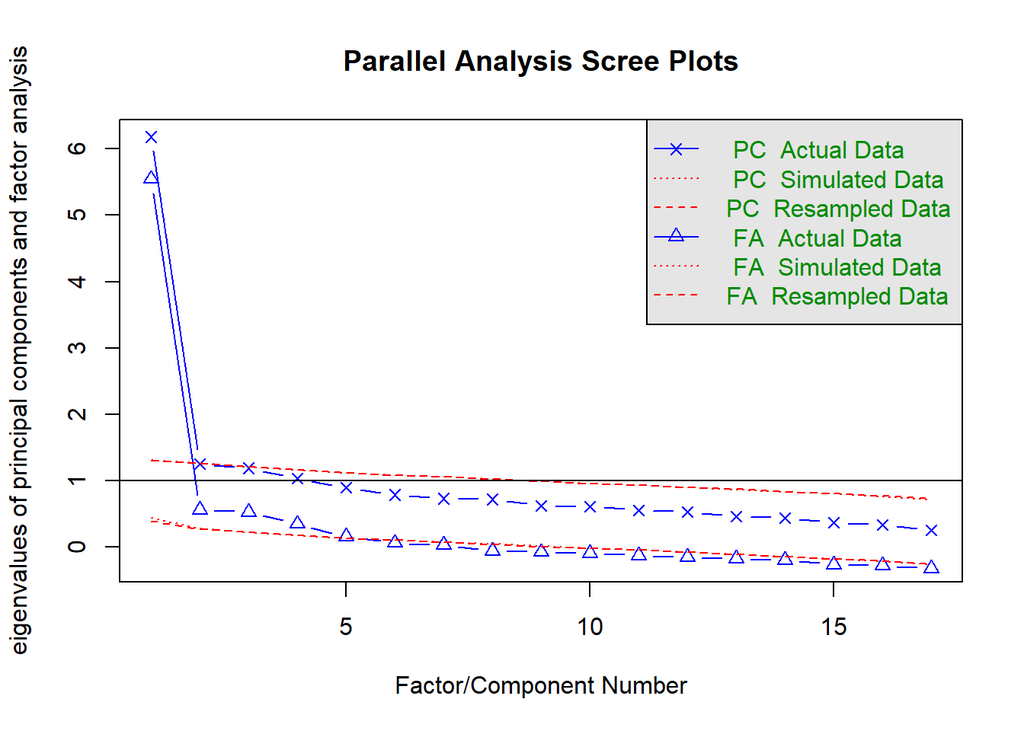

```
## Parallel analysis suggests that the number of factors =  4  and the number of components =  1
```

```r
set.seed(1234)
fa.parallel(dat)
```

# Das graded response model (GRM): model fit

Was wir jetzt zunächst einmal fitten möchte, ist ein eindimensionales Modell, denn die eine Komponente der PCA ist doch zu verführerisch, um ihr nicht den Vorrang zu geben und zu sagen “alles ist eindimensional genug”.

```r
# gmodel1 <- mirt(dat, 1, "graded", TOL = .0001)
summary(gmodel1)
##          F1    h2
## Q1A   0.655 0.429
## Q2A   0.679 0.461
## Q3A   0.490 0.240
## Q4A   0.628 0.394
## Q5A   0.457 0.209
## Q6A   0.749 0.561
## Q8A   0.459 0.211
## Q9A  -0.691 0.478
## Q10A  0.766 0.587
## Q11A  0.693 0.481
## Q12A  0.522 0.273
## Q13A -0.662 0.438
## Q15A -0.673 0.453
## Q16A  0.596 0.355
## Q17A  0.825 0.681
## Q18A  0.440 0.193
## Q19A  0.733 0.537
##
## SS loadings:  6.98
## Proportion Var:  0.411
##
## Factor correlations:
##
##    F1
## F1  1
# (m2.gmodel1<-M2(gmodel1, type = "C2"))
m2.gmodel1
##             M2  df p      RMSEA   RMSEA_5   RMSEA_95      SRMSR       TLI
## stats 478.7592 119 0 0.07434279 0.0673893 0.08129151 0.06275646 0.8971765
##             CFI
## stats 0.9100295
itemfit(gmodel1, method = "PV_Q1")
##    item    S_X2 df.S_X2 RMSEA.S_X2 p.S_X2
## 1   Q1A  90.209      94      0.000  0.592
## 2   Q2A  96.179      76      0.022  0.059
## 3   Q3A 105.028     104      0.004  0.453
## 4   Q4A  84.754      93      0.000  0.717
## 5   Q5A 112.194     116      0.000  0.583
## 6   Q6A  63.159      77      0.000  0.872
## 7   Q8A  93.221     102      0.000  0.721
## 8   Q9A  85.313      85      0.003  0.470
## 9  Q10A 106.672      79      0.025  0.021
## 10 Q11A  55.734      89      0.000  0.998
## 11 Q12A  82.253     105      0.000  0.951
## 12 Q13A 100.341      96      0.009  0.361
## 13 Q15A 118.786     103      0.017  0.137
## 14 Q16A  87.002      86      0.005  0.449
## 15 Q17A  96.273      74      0.023  0.042
## 16 Q18A  96.974     111      0.000  0.826
## 17 Q19A  85.034      85      0.001  0.479
```

Die summary-Funktion zeigt uns zweierlei: 1. ein eindimensionales Modell erklärt immerhin 41% der Varianz in den Daten und 2. alle Items laden hinreichend gut auf diesem Faktor. “M2” gibt uns einige CFA Fit Indizes, und wie wir sehen, fittet das eindimensionale GRM Modell ziemlich gut! Aber, aber: wir haben ja auch schon 2 Items ausgeschlossen. Und dennoch Raum nach oben ist auch hier noch.

# The graded response model: person parameters

Jetzt schauen wir einmal in Richtung Benutzbarkeit der Skala. Wir schauen uns hierfür die Reliabilität der Skala an und außerdem die Verteilung der (latenten) Faktorscores einzelner Personen, also deren Theta-Werte an.

Innerhalb der IRT gibt es eigentlich keinen einen natürlichen Wert, um die Messgenauigkeit eines Instruments unabhängig der Personenfähigkeit angibt. Stattdessen, liefert jedes einzelne Item für unterschiedliche Personenfähigkeiten unterschiedlich viel Information (hierbei können wir die statistische Information, die Fischer-Information, relativ unproblematisch als alltagssprachliche Information auffassen). Manche Items helfen uns also sehr gut im oberen Bereich zu differenzieren, umgekehrt aber im unteren Bereich nicht so sehr; oder auch anders herum. Grundsätzlich ist diese Auffassung der Messgenauigkeit sehr intuitiv. Wir stellen uns vor, wir möchten die Mathematikfähigkeit von Gymnasiasten in Erfahrung bringen. Dazu stellen wir ihnen die Frage “Was ergibt 2+2?”. Wahrscheinlich (und hoffentlich) wird jeder diese Frage korrekt beantworten, denn sie ist viel zu einfach für diese Zielgruppe. Wir haben dann keine Grundlage um einem Schüler zu attestieren, er sei mehr oder weniger mathebegabt als ein anderer. Die Beantwortung von 2+2 liefert uns also keine Information. Schön ist nun, dass diese plausible Annahme innerhalb der IRT ebenfalls gilt. Unschön ist, dass man nicht direkt einen Wert anschauen kann, um die Messgenauigkeit des Tests zu beurteilen. Aber es gibt auch innerhalb der IRT Abhilfe, indem man sich die marginale bzw. empirische Reliabilität anschaut, die man “ganz normal” wie andere Reliabilitäten interpretieren kann.

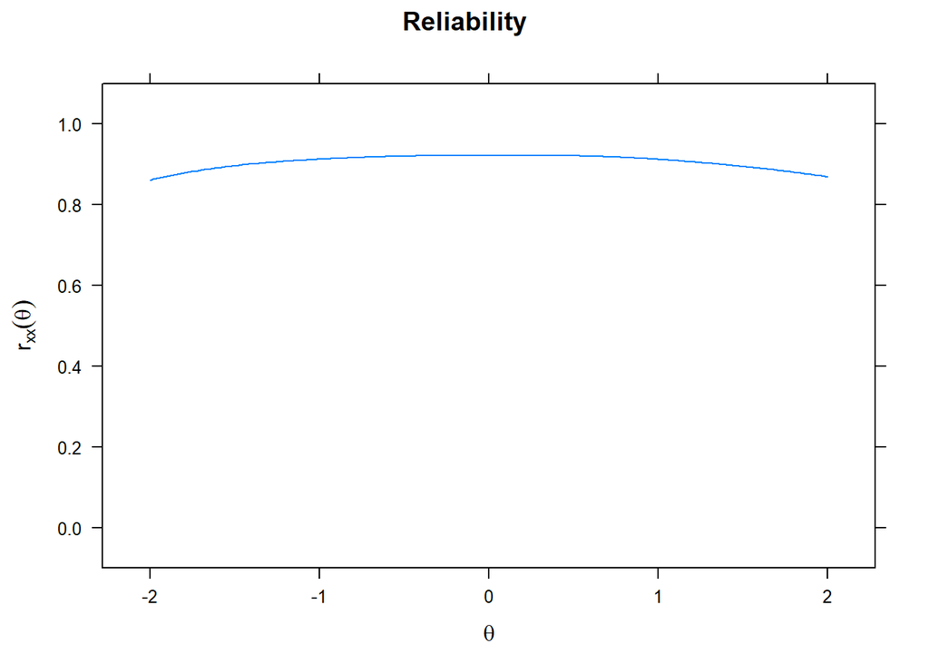

```r
empirical_rxx(thetgm1)
##        F1
## 0.9083824
plot(gmodel1, type = "rxx", theta_lim = c(-2,2) )
```

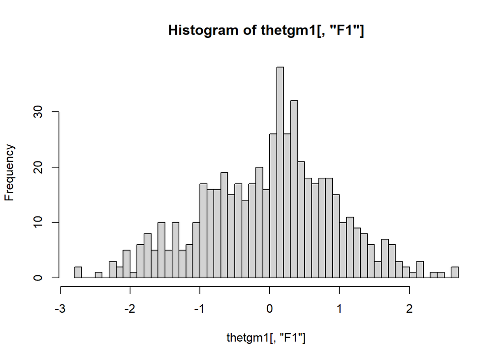

```r
# thetgm1 <- fscores(gmodel1, full.scores.SE = TRUE, method = "EAP")

hist(thetgm1[,"F1"], breaks = 40)
```

# The graded response model: short summary

Bisher lief alles glatt. Die Reliabilität ist in Ordnung, der Modellfit ist in Ordnung, wir haben eine schöne einzelne Dimension protestantischer Arbeitsethik. Aber mehr leider auch nicht. Spannend wäre jetzt zu untersuchen, inwiefern die psychologische Dimension, die wir gefunden haben mit anderen Dimensionen zusammenhängt und letztlich noch viel mehr, ob sie auch mit anderen Ereignissen, als der Beantwortung irgendwelcher Fragebögen einhergeht. Ob also beispielsweise Personen, die einen hohen Wert auf der PWES haben im echten Leben erfolgreich sind, viel arbeiten (work hard, play hardly) etc. Leider ist uns die Untersuchung des Letzteren vergönnt, da wir hierzu keine Daten haben. Eine Minivalidierung der PWES können wir dennoch in Angriff nehmen.